# 40080 LC Statistics

Ed Mason

Last updated: 2025-02-13

# Statistics Lecture 02, 30/01/2025

## Normal Distribution

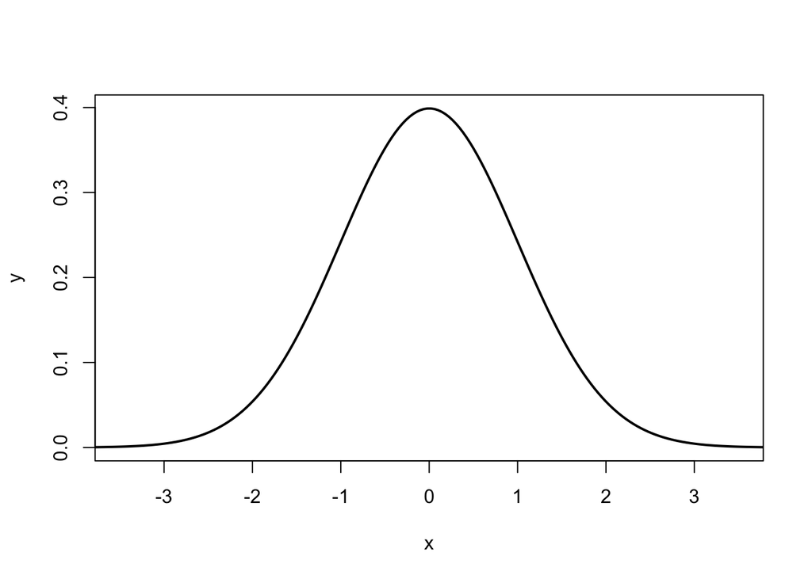

```r
x <- seq(-4, 4, length=200)
y <- dnorm(x, mean=0, sd=1)
plot(x,y, type = "l", lwd = 2, xlim = c(-3.5,3.5))
```

## Dataset samples

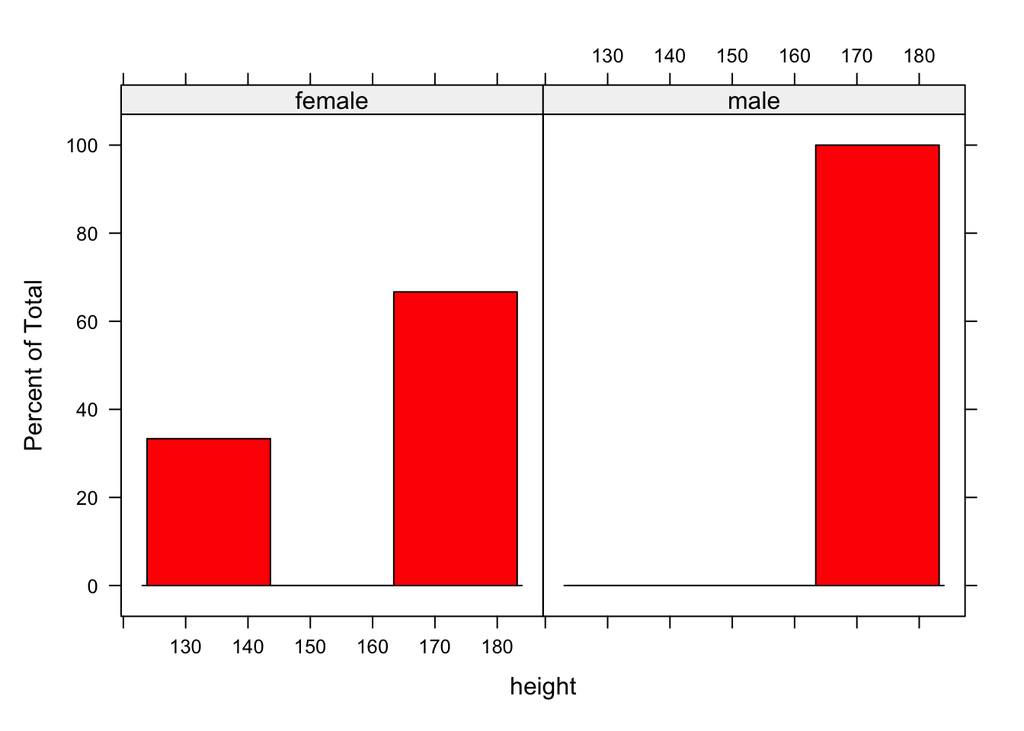

```r
#include sample height data in data frame
height<-c(126,178,181,167,166)
gender<-c("female","female","male","female","male")
lat<-c(-43.67327,43.42426,51.79624,0.84228,-49.05650)
long<-c(-114.51627,-95.23205,-43.43058,-91.71106,-23.16819)
data<-data.frame(height,gender,lat,long)

histogram(~height|gender,data=data, main="", col="red")
```

# Statistics Lecture 03, 06/02/2025

## Hypothesis Testing

Are two samples similar or different?

### Example: Agricultural Land Use

```r
lowland_clay_sample <- c(10,20,25,25,30,35,45,50,50,60)
upland_limestone_sample <- c(25,30,30,40,40,50,50,60,60,65)
percentage_meadow <- data.frame(lowland_clay_sample, upland_limestone_sample)
```

Statistical hypothesis testing gives an objective method to see if something is due to chance or is genuinely statistically significant

### Six Stages

1. State null hypothesis
2. State alternative hypothesis
3. Decide upon a rejection level (α)
4. Conduct statistical test (Do the Maths)
5. Determine whether to accept or reject the null hypothesis
6. Draw a physical process-based conclusion from the results

#### 1. State null hypothesis

There is no significant difference between meadow percentage in lowland and upland areas. Hₒ: μ(lowland) = μ(upland)

#### 2. State alternative hypothesis

There **is** a significant difference between meadow percentage in lowland and upland areas. Hₐ: μ(lowland) != μ(upland)

##### Non-directional or Directional Tests

```r
# make into table
```

| Non-directional | Directional |
| --- | --- |
| Do NOT state which variable is greatest in Ha | State which |

#### 3. Decide upon a rejection level

Probability of Hₒ being true = 0.024

Probability of Hₐ being true = 0.976

The purpose of this test is to find out which hypothesis **is most likely** to be correct. (Conclusions are probabilistic not absolute).

##### Statistical significance levels

- Usually scientists use α = 0.05 - the 95% statistical significance level (confidence level).
- Leaves room for 5% error in our conclusion.
- Second most commonly used is α = 0.01 - the 99% confidence level.

###### Types of Error

Type I Error - Should have retained Hₒ

Type II Error - Should have rejected Hₒ

95% level is the best level for the trade-off between Type I and Type II errors

(90% more likely Type I; 99.9% more likely Type II)

#### 4. Conduct Statistical Test

Example: Ag. Land Use Problem: Comparing means between two samples

I.e. Is there a significant difference between the two samples?

## The Student’s *t* test

### Assumptions

Before you do the test, have you satisfied the assumptions?

1. Each sample is taken from a population that is normally distributed
2. Interval/ratio data, cannot use data in categories
3. Each observation is independent of the other observations in the same sample
4. The samples are taken from populations which have similar variances

#### 1. Normality

1. Plot the data (Plot a histogram of each variable)

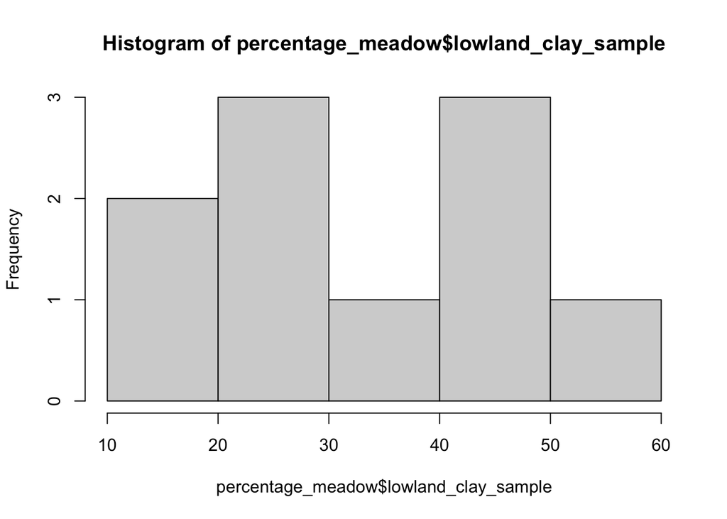

```r
# why is this splitting?
# histogram(~lowland_clay_sample|upland_limestone_sample,data=percentage_meadow,main="")
hist(percentage_meadow$lowland_clay_sample)
```

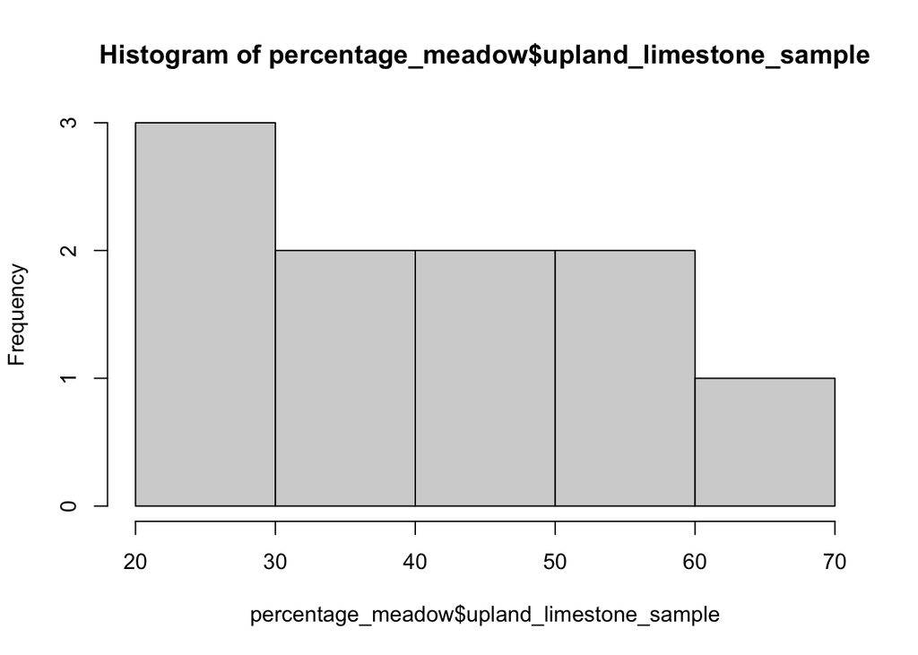

```r
hist(percentage_meadow$upland_limestone_sample)
```

```r
stat.desc(percentage_meadow$lowland_clay_sample)
```

```
##      nbr.val     nbr.null       nbr.na          min          max        range
##    10.000000     0.000000     0.000000    10.000000    60.000000    50.000000
##          sum       median         mean      SE.mean CI.mean.0.95          var
##   350.000000    32.500000    35.000000     5.000000    11.310786   250.000000
##      std.dev     coef.var
##    15.811388     0.451754
```

```r
stat.desc(percentage_meadow$upland_limestone_sample)
```

```
##      nbr.val     nbr.null       nbr.na          min          max        range
##   10.0000000    0.0000000    0.0000000   25.0000000   65.0000000   40.0000000
##          sum       median         mean      SE.mean CI.mean.0.95          var
##  450.0000000   45.0000000   45.0000000    4.4721360   10.1166744  200.0000000
##      std.dev     coef.var
##   14.1421356    0.3142697
```

3. Calculate Z score of skewness statistic
4. The Kolmogorov-Smirnov Test (K-S Test)

#### 4. Similarity of Variances

The *t* test -> comparing arithmetic means of two samples

So samples need an equal variance

**Rule:** Variances must differ by less than a factor of two

Formal test for this -> Levene’s Test

### Pick which form of test

One- or two-sample test (comparison to popln. mean or one another)

Independent samples or Paired samples (samples are independent of each other or are paired - measured at the same time)

$$t = \frac{\text{difference between the means}}{\text{standard error of
the difference}}$$
Lowland Clay: Arithmetic Mean = 35% Standard Deviation = 15.81% Number of Observations = 10

Upland Limestone: Arithmetic Mean = 45% Standard Deviation = 14.14% Number of Observations = 10

# Statistics Lecture 04, 13/02/2025

## Anaylsis of Variance (ANOVA)

ANOVA determines whether the means of several populations are equal.

NB. Student’s *t* test compares the means of two samples **only**.

### Two forms of ANOVA

1. One-way ANOVA **i. Independent samples (THIS LECTURE)**
2. Paired samples (Repeated Measures ANOVA)
2. Two-way ANOVA

### One-way ANOVA: Independent Samples

- Each observation is classified into one sample or another based on ONE criterion.

E.g. crop yield per acre obtained on different soil types

```r
soil_type <- c('A','A','A','A','A','B','B','B','B','B','C','C','C','C','C')
as.factor(soil_type)
```

```
##  [1] A A A A A B B B B B C C C C C
## Levels: A B C
```

```r
crop_yield <- c(24,27,21,22,26,17,25,24,19,28,19,18,22,24,23)
table1 <- data.frame(soil_type, crop_yield)
```

ANOVA separates the total variance into two components:

1. Variance between the samples
2. Variance within the samples

$$\text{Total variance} = \text{Variance between samples} + \text{Variance
within samples}
\newline
\text{TSS} = \text{SSC} + \text{SSE}$$

#### Assumptions of ANOVA

1. The errors (residuals) are normally distributed. This is more likely to be achieved when random samples from normal populations are used. For each sample:
- Plot a histogram
- Calculate the skewness value
- Calculate the Z score of skewness
- Perform either the K-S test or the Shapiro-Wilk test
2. The normal populations all have an equal or COMMON VARIANCE.
- Variance ratio
- Levene’s Test

NB. If you cannot satisfy these assumptions, you need to do another test (see end of lecture).

#### Reminder: What is Variance?

$$\text{Variance} = (\text{Standard Deviation})^2 = σ^2$$

##### Calculating the Total Sum of Squares

The Total Sum of Squares (TSS) is the sum of the squared differences between each observation and the overall mean.

##### Calculating the Sum of Squares Between the Columns (SSC)

SSC -> The variation between the samples

$$\text{SSC} = \sum_{i=1}^{k} n_i(\bar{X}_i - \bar{X})^2$$

If SSC is small, the samples have similar means.

IF SSC is large, the samples have different means.

If SSC is zero, the samples have the same mean.

##### Calculating the Error Sum of Squares (SSE)

SSE -> The variation within the samples

#### Worked Example

$$\text{TSS} = \text{SSC} + \text{SSE}
\newline
153.6 = 19.6 + 134.0$$

```r
19.6 + 134.0
```

```
## [1] 153.6
```

#### ANOVA Table

Need to use Degrees of Freedom to calculate the Mean Sum of Squares

Then we can run Snedecor’s Variance Ratio Test (*F*)

$$F = \frac{\text{Mean Sum of Squares between samples}}{\text{Mean Sum of
Squares within samples}} = \frac{\text{Systematic
Differences}}{\text{Random Variations}}$$

#### Conclusions

1. The null hypothesis must be retained.
2. There is no significant difference in crop yields between the three soil types.
3. The differences observed between the samples are a product of random chance and do not reflect a real difference in crop yield with soil type.

### Arranging In R

Values in one column, factor in another (see table1)

```r
print(table1)
```

```
##    soil_type crop_yield
## 1          A         24
## 2          A         27
## 3          A         21
## 4          A         22
## 5          A         26
## 6          B         17
## 7          B         25
## 8          B         24
## 9          B         19
## 10         B         28
## 11         C         19
## 12         C         18
## 13         C         22
## 14         C         24
## 15         C         23
```

```r
res<-aov(crop_yield~soil_type, data = table1)
summary(res)
```

```
##             Df Sum Sq Mean Sq F value Pr(>F)
## soil_type    2   19.6    9.80   0.878  0.441
## Residuals   12  134.0   11.17
```

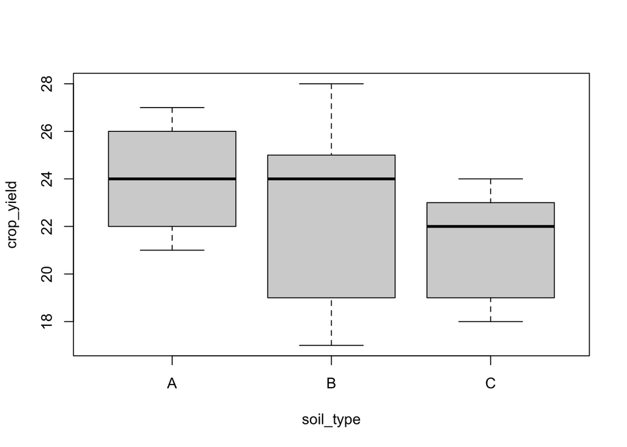

```r
boxplot(crop_yield~soil_type, data = table1)
```

### What if Assumptions are not met? 1. Transform all of the samples (e.g. log base 10) and then test assumptions again 2. Use a non-parametric test (e.g. Kruskal-Wallis Test)

### Kruskal-Wallis Test

Only use if you CANNOT use a parametric test

```r
kruskal.test(crop_yield~soil_type, data = table1)
```

```
##
##  Kruskal-Wallis rank sum test
##
## data:  crop_yield by soil_type
## Kruskal-Wallis chi-squared = 1.7639, df = 2, p-value = 0.414
```

The bigger the value, the bigger the difference between the samples

### Post-hoc Tests

If you have more than two samples, you need to do a post-hoc test to see which samples are different from each other

#### Tukey Test

```r
TukeyHSD(res)
```

```
##   Tukey multiple comparisons of means
##     95% family-wise confidence level
##
## Fit: aov(formula = crop_yield ~ soil_type, data = table1)
##
## $soil_type
##     diff       lwr      upr     p adj
## B-A -1.4 -7.038394 4.238394 0.7890417
## C-A -2.8 -8.438394 2.838394 0.4089635
## C-B -1.4 -7.038394 4.238394 0.7890417
```